# main.

Molly K

04/11/2020

# 1 Introduction

In this review I will be looking into data collected concerning **chaffinches**. Chaffinches are a member of the Finch family often recognizable by the coloring of their plumage or loud song (rspb, n.d.).  
The data set used for this analysis (called chaff) has recorded the **masses** of both male and female chaffinches, see Figures1.1, and 1.2.  
Working with the **chaff** data set, this data records the masses of male and female chaffinches. Before beginning this analysis I *hypothesized* that the **males** would be **heavier** than the females. Previous studies of chaffinches have displayed that the male birds tend to have a higher average weight (Garcia‐Del-Rey and Gosler 2005).

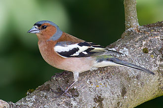

Figure 1.1: Male Chaffinches have a recognisable red plumage, Photo from Wikipedia, Common Chaffinch, https://en.wikipedia.org/wiki/Common_chaffinch

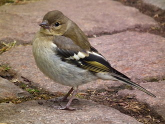

Figure 1.2: Female Chaffinches have a borwn plumage unlike the males, Photo from Wikipedia, Common Chaffinch, https://en.wikipedia.org/wiki/Common_chaffinch

## 1.1 Methods

Use R analysis within *Rmarkdown* (Allaire et al. 2019) to calculate the **sum of squares** from the **mass** values.

```
## 'data.frame':    20 obs. of  2 variables:
##  $ females: num  18.3 22.1 22.4 18.5 22.2 19.3 17.8 20.2 22.1 16.6 ...
##  $ males  : num  22.7 20.6 25.4 20.4 21.6 17 26.4 20.4 24.7 21.8 ...
```

```
## tibble [40 x 2] (S3: tbl_df/tbl/data.frame)
##  $ sex : chr [1:40] "females" "males" "females" "males" ...
##  $ mass: num [1:40] 18.3 22.7 22.1 20.6 22.4 25.4 18.5 20.4 22.2 21.6 ...
```

```
## # A tibble: 1 x 1
##      ss
##   <dbl>
## 1  207.
```

```
## # A tibble: 2 x 2
##   sex        ss
##   <chr>   <dbl>
## 1 females  86.8
## 2 males    87.9
```

```
## # A tibble: 2 x 5
##   sex     mean_index     n    sd    se
##   <chr>        <dbl> <int> <dbl> <dbl>
## 1 females       20.5    20  2.14 0.478
## 2 males         22.3    20  2.15 0.481
```

### 1.1.1 Results

Summary of data shows a **mean** of 20.480 for **females** and for **males** 22.275 . With **males** having a *Standard deviation* of 2.151 and a *Standard error* of 0.481. For females the results were, a *Standard deviation* of 2.138 and a *Standard error* of 0.478.

#### 1.1.1.1 Discussion

**Male** chaffinches appear to be *heavier* than **Females** from this data, having a *higher* mean **mass**. Despite having *slightly higher* standard deviations and standard errors the results are conclusive.

##### References

Allaire, JJ, Yihui Xie, Jonathan McPherson, Javier Luraschi, Kevin Ushey, Aron Atkins, Hadley Wickham, Joe Cheng, Winston Chang, and Richard Iannone. 2019. *Rmarkdown: Dynamic Documents for R*. https://github.com/rstudio/rmarkdown.

Garcia‐Del-Rey, Eduardo, and Andrew G. Gosler. 2005. “Biometrics, Ageing, Sexing and Moult of the Blue Chaffinch Fringilla Teydea Teydea on Tenerife (Canary Islands).” https://doi.org/10.1080/03078698.2005.9674329.

rspb. n.d. “Chaffinch Bird Facts.” https://www.rspb.org.uk/birds-and-wildlife/wildlife-guides/bird-a-z/chaffinch/.